# Problem set 1 key: Botsford et al. and Vendermeer and Goldberg pp.1—8

# From Botsford et al.

## 1. *On Exactitude in Science*

In 1946, Argentine writer Jorges Luis Borges wrote a short story, *On Exactitude in Science*. If follows in its entirety:

> …In that Empire, the Art of Cartography attained such Perfection that the map of a single Province occupied the entirety of a City, and the map of the Empire, the entirety of a Province. In time, those Unconscionable Maps no longer satisfied, and the Cartographers Guilds struck a Map of the Empire whose size was that of the Empire, and which coincided point for point with it. The following Generations, who were not so fond of the Study of Cartography as their Forebears had been, saw that that vast Map was Useless, and not without some Pitilessness was it, that they delivered it up to the Inclemencies of Sun and Winters. In the Deserts of the West, still today, there are Tattered Ruins of that Map, inhabited by Animals and Beggars; in all the Land there is no other Relic of the Disciplines of Geography.

Please read it over a few times, (1.1) summarize its main point, and (1.2) then relate this passage and relate it to §1 of Botsford et al. in no more than 2 or 3 paragraphs.

### Answers

> 1.1. The main point is that models can become so realistic that they lose their usefulness.  
> 1.2. This relates to §1 of Botsford et al. as being an example of a model that is realistic and precise in Levins’ framework, and it sacrifices generality. Botsford et al. themselves see the value of models as helping understand or making predictions, which this map doesn’t do. In May and Holling’s view, this would be a tactical model. But, in general, this story illustrates the absuridty of extreme realism. But, I’m curious to see how y’all compared: there could be many ways.

## 2. Levins’ tradeoffs

Subsection 1 of Botsford et al. describes Levins’ observation of models (in population biology) that they tend to maximize two and sacrifice one of the following characteristics: *generality*, *precision*, and *realism*. For the the following philosophical questions, rather than spending time solving them analytically or computationally, I ask that you spend time thinking through and refining your answers.  
2.1 Describe each of these characteristics individually, *in your own words*,  
2.2 Describe the three types of models you can have by maximizing two and sacrificing one of the characteristics, *in your own words*, and  
2.3 *In your own words*, describe why we cannot simultaneously maximize all three characteristics in a model.

Please note that I understand you have limited exposure to modeling—the matter of this course—so I am expecting reflection, speculation, analogy, and recall from from other coursework and life experience. The point of this question is for you to think deeply more than it is for you to be Correct.

### Answers

> 2.1. **Generality**: the ability of a model to be applied across different ecological scenarios. **Realism**: how much biology is included in the model. **Precision**: the extent to which the quantitative (precise) and qualitative (imprecise) results are valued and used from a model’s output.  
> 2.2. A model can maximize **generality and realism, sacrificing precision** with models that have general charactieristics of real populations, but their results are interpreted qualitatively (grow, shrink, cycle, higher or lower equilibirum, etc.), like logistic growth or competitiion models. A model can maximize **precision and realism, sacrificing generality**, with management models being a good example of this where they model a specific system and use teh quantitative output of these models to make management decisions. A final model can maximize **precision and generality, sacrificing realism**, which, according to Levins, are not useful. These, to him, are models that are doing theory for theory’s sake, which is not realistic. 2.3. I have no idea: you just can’t. But, I hope that you think about this problem and arrive at an answer that is suitable to you.

# From concepts from Vandermeer and Goldberg

## 3. Relating population abundance and densities

We will be using population *abundance* and *density* interchangeably throughout the semester. We do this because both are used by ecologists in basic (e.g., academic, some government) and applied (e.g., academic, government, private) work. Density is, as you have been taught, the abundance per unit area. To do some of these calculations and practice some calculations in R and using R code chunks, please calculate the following:

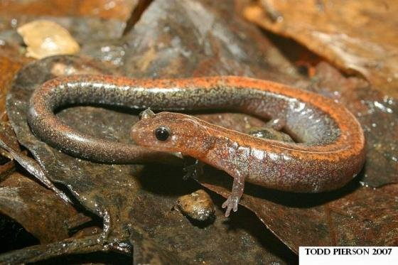

(So cute OMG)

3.1. Abundances of eastern red-backed salamanders (*Plethodon cinereus*; ERB for short) are higher than any other vertebrate animal species in the state of Maine. Curiously, it also has the highest biomass of any other vertebrate animals species as well. ERB densities have been estimated as high as 2.8 individuals/m<sup>2</sup> at Mountain Lake Biological Station in Virginia. This makes it the most abundant vertebrate species at the site, and more abundant than all birds and mammals combined (Hairston 1996; Jaeger et al. 2002). What would be the abundance of ERBs of the entire station if its area is 40,470 ha? Please show your work in an Rmarkdown chunk and end the chunk with `print(object_name)` where the `object_name` is whatever you call your abundance.  
3.2. What is the density of ERBs in units of km<sup>2</sup>? Please show your work in an Rmarkdown chunk.  
3.3. At the Hubbard Brook Experimental Forest in New Hampshire, the estimate for the population density of ERBs is 2,583 individuals/hectare, which corresponds to a biomass of 1,658 grams/hectare. This biomass is approximately 2.4 times that for all birds and approximately equal to that for mice and shrews (Burton and Likens 1975). The Hubbard Brook Experimental Forest is 3,138 ha. What would be the abundance of ERBs of the entire experimental forest? What would be the average mass of an individual? Please show your work in an Rmarkdown chunk.  
3.4. OK, last two arithmetic questions 😉. (BTW, if you install the `emo` package, you can insert emojis in your text like what I just did as `emo::ji("wink")`.) We are in Maine, and the only animal that is in competition for being the most iconic next to lobstah is moose (*Alces alces*). They are magnificent creatures: adult moose stand at 4’7”—6’11” at the shoulder and between 440—1,500+ pounds (source: [Wikipedia](https://en.wikipedia.org/wiki/Moose)). The last official estimate of population size we have in Maine is a 2012 estimate that there were 76,000 individuals [link](https://www.maine.gov/ifw/fish-wildlife/wildlife/species-information/mammals/moose.html). What would be the density of moose in the state of Maine in individuals/hectare if the state is 35,385 mi<sup>2</sup>? Please show your work in an Rmarkdown chunk.  
3.5. Your campus is 289 ha (714 acres). Given the density you calculated above, how many moose do you expect to see on campus? Please show your work in an Rmarkdown chunk.  
3.6. Please reconcile your previous answer (3.5) with the sightings of moose on campus? Why might we not see as many as you expect through your calculation? In other words, tell me about the ecology or assumptions of the inference we just made.

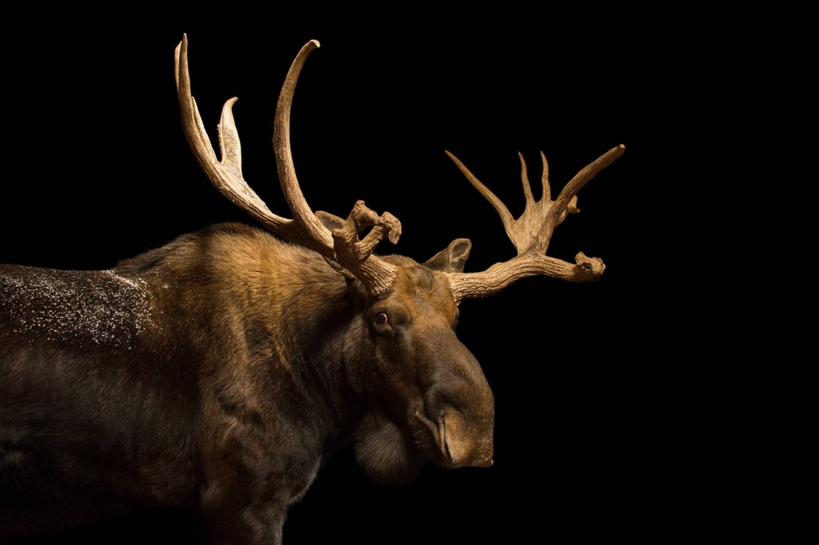

(Photo: [Joel Sartore](https://www.joelsartore.com/))

Data and some verbiage on ERBs is respectfully used and adapted from [amphibiaweb.org](https://amphibiaweb.org/cgi/amphib_query?where-genus=Plethodon&where-species=cinereus).

### Answers

> 3.1.

> ```r
> # Make a variable for the density
>   densm2 <- 2.8 # individuals / m^2
> # Let's first convert m^2 to ha. A ha is 100 x 100 m, so there are 10,000 m^2 in a ha.
>   ha <- 100 * 100
>   densha <- densm2 * ha # In terms of units, (that's individuals / m^2)(m^2 / ha)
> # The size of MLBS times the density (inds / ha)
>   MLBS_area <- 40470 # ha
>   MLBS_abundance <- MLBS_area*densha
>   print(MLBS_abundance)
> ```

> ```
> ## [1] 1133160000
> ```

> This is over 1.1 **b**illion individuals!

> 3.2.

> ```r
> # Note you can use variables beween chunks, so you don't need to make a new density / m^2
>   km2 <- 1000 * 1000 # Unts is m for each 1000 since a km = 1000 m
> # Convert ha to km^2
>   denskm2 <- densm2 * km2 # In terms of units, (that's individuals / m^2)(m^2 / km^2)
>   print(denskm2)
> ```

> ```
> ## [1] 2800000
> ```

> This is over 2.8 million individuals per km<sup>2</sup>!

> 3.3.

> ```r
> # First question
>   # Givens: density and area
>     dens <- 2583 # ind/ha
>     area <- 3138 # ha
>     adundance <- dens * area
> # Second quesiton
>   # Givens: mass density and dens of inds above
>   massDens <- 1658 # g ERB / ha
>   massInd <- massDens / 2583 # this is g / ind since the ha cancel
> ```

> The number of individuals at Hubbary Book is 8.11 million! The mass per individual is 0.64 grams. (So cute.)

> 3.4.

> ```r
> # Givens: abundance and area
>   inds <- 76000
>   ME_area <- 35385 # miles^2
> # Since we want inds / ha, we first need to convert miles^2 to ha
>   haPerMi <- 259 # roughly
>   ME_area_ha <- ME_area * haPerMi # takes mi^2 * (ha / mi^2)
> # To find density, it's individuals / area
>   dens_moose <-  inds / ME_area_ha # units of inds / area
>   print(dens_moose)
> ```

> ```
> ## [1] 0.008292675
> ```

> This is about 0.0083 individual moose per hectare in Maine.

> 3.5.

> ```r
> # Finding the number of moose on campus is multiplying density times area
>   colby_area <- 289
>   moose_colby <- dens_moose * colby_area
>   print(moose_colby)
> ```

> ```
> ## [1] 2.396583
> ```

> According to our correct math, there is about 2.4 moose on Colby College’s campus.

> 3.6. There is not a uniform distirbution (i.e., evenly spaced) of moose on the landscape; i.e., we neglect the ecology of the individuals where they have habitat preferences and are clustered on the landscape of Maine. They are mostly in areas that are not cities, where there is suitable food and habitat.

## 4. BIDE, $\lambda$, and introducing $\LaTeX$ for writing math

The canonical equation describing population change is the *BIDE* equation:
$$N_{t+1} = N_t +
bN_t - dN_t + I - E.$$
That is, the population at the next timesetp, $N_{t+1}$ is a function of the current population size, $N_t$, plus the number of births per individual, $bN_t$, plus the immigrants into the population, $I$, and minus the number of emigrants that leave the population, $E$. For the sake of this class—and most population-level studies—we ignore migration (it has a time and place, and we’ll touch on it a bit in this class). So, what we’re left with is:
$$N_{t+1} = N_t + bN_t - dN_t.$$

Now, compare this with equation (3) in your book. Please use algebra to determine what the finite rate of growth, $\lambda$, is equal to from the last equation ($N_{t+1} = N_t + bN_t - dN_t$). Write what you did and the math using $\LaTeX$. Do this by writing your math between dollar signs; e.g., `$N_{t+1} = N_t + bN_t - dN_t$` is how I wrote our last equation. It’ll only be one or two steps, but I want you to play around with $\LaTeX$ to start writing math.

### Answers

> If you take the BIDE equaiton, $N_{t+1} = N_t + bN_t - dN_t$, and factor out $N_t$ on the right-hand side, you are left with $N_{t+1} = (1 + b - d)N_t$. Equation 3 in the book is $N_{t+1} = \lambda N_t$. If we substute for $N_{t+1}$ we get $\lambda N_t = (1 + b - d)N_t$. Last, if we divide both sides by $N_t$, we are left with $\lambda = 1 + b - d$.

## 5. Simulating and graphing discrete-time density-independent growth

Below is how one would simulate population growth starting with 42 individuals over 20 years with a finite rate of growth as 1.1. We use what’s called a “for loop” to iterate an operation. In this case, we are computing `Ntp1`, abbreviated for $N_{t+1}$, from `Nt` times the finite rate of growth, $\lambda$.

```r
# Create an empty vector for 20 years
  years <- 20
  year_vec <- 1:years
  N_vec <- rep(x = NA, times = years)
# Set the initial population size at the first year
  N_vec[1] <- 42
# Set the parameters
  lambda <- 1.1
# Write a "loop" that iterates with "i", in this case, taking the value of every year
  for (i in 2:years) {
    Nt <- N_vec[i - 1]
    Ntp1 <- lambda*Nt
    N_vec[i] <- Ntp1
  }
# Plot the timeseries
  plot(x = year_vec, y = N_vec, pch = 19, las = 1, xlab = "Time (years)", ylab = "Density (N)")
```

For this problem, please modify the code above to plot three different values of the finite rate of growth, $\lambda = 1.1, 0.55, \text{and}~1.65$. Please plot all three values on the same plot by, for each subsequent simulation, use `points()` to add the points. `points()` takes many of the same arguments as `plot()`; e.g., `x =`, `y =`, `col =`, `pch =`, etc.

### Answers

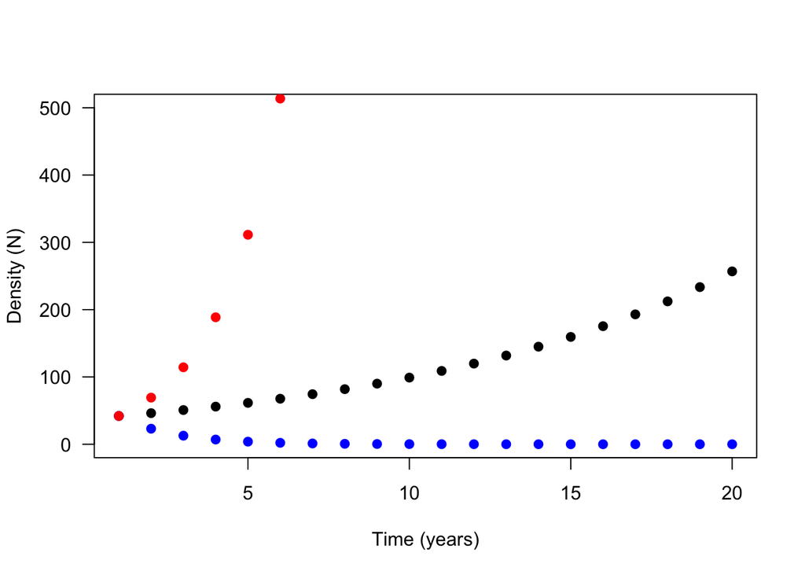

> ```r
> # Create empty vectors for 20 years
>   years <- 20
>   year_vec <- 1:years
>   N_vec1 <- rep(x = NA, times = years)
>   N_vec2 <- rep(x = NA, times = years)
>   N_vec3 <- rep(x = NA, times = years)
> # Set the initial population size at the first year
>   N_vec1[1] <- 42
>   N_vec2[1] <- 42
>   N_vec3[1] <- 42
> # Set the parameter values for each lambda
>   lambda1 <- 1.1
>   lambda2 <- 0.55
>   lambda3 <- 1.65
> # Write a "loop" that iterates with "i", in this case, taking the value of every year
>   for (i in 2:years) {
>     Nt <- N_vec1[i - 1]
>     Ntp1 <- lambda1*Nt
>     N_vec1[i] <- Ntp1
>   }
>   for (i in 2:years) {
>     Nt <- N_vec2[i - 1]
>     Ntp1 <- lambda2*Nt
>     N_vec2[i] <- Ntp1
>   }
>   for (i in 2:years) {
>     Nt <- N_vec3[i - 1]
>     Ntp1 <- lambda3*Nt
>     N_vec3[i] <- Ntp1
>   }
> # Plot the timeseries
>   plot(x = year_vec, y = N_vec1, pch = 19, las = 1, xlab = "Time (years)", ylab = "Density (N)", ylim = c(0, 500))
>     points(x = year_vec, y = N_vec2, col = "blue", pch = 19)
>     points(x = year_vec, y = N_vec3, col = "red", pch = 19)
> ```

## References

Hairston, N.G. (1996). Long-term studies of vertebrate communities. Academic Press, New York, NY.

Jaeger, R.G. and M.G. Peterson (2002). ‘’Familiarity affects agonistic interactions between female Red-Backed Salamanders.’’ Copeia, 2002(3), 865-869.

Burton, T.M. (1975). ‘’Salamander populations and biomass in the Hubbard Brook Experimental Forest, New Hampshire.’’ Copeia, 1975(3), 541-546.